# Exercise 3 (Logistic regression)

Exercice 3 analysis

### 3.2 Read Data

Start by reading the dataset and looking up the variable names

```r
alc <- read.table("http://s3.amazonaws.com/assets.datacamp.com/production/course_2218/datasets/alc.txt", header=TRUE,  sep = ",")
colnames(alc)
```

```
##  [1] "school"     "sex"        "age"        "address"    "famsize"
##  [6] "Pstatus"    "Medu"       "Fedu"       "Mjob"       "Fjob"
## [11] "reason"     "nursery"    "internet"   "guardian"   "traveltime"
## [16] "studytime"  "failures"   "schoolsup"  "famsup"     "paid"
## [21] "activities" "higher"     "romantic"   "famrel"     "freetime"
## [26] "goout"      "Dalc"       "Walc"       "health"     "absences"
## [31] "G1"         "G2"         "G3"         "alc_use"    "high_use"
```

The dataset describes students in two Portuguese schools. Each observation describes a single student, including their age, gender, performance at school. For this exercise we’ll be mainly looking at alcohol consumption.

### 3.4 Hypotheses about alcohol use

Specifically, we’ll examine the relationship between high alcohol consumption and final student grades (G3), family relationship (famrel), absences, and age.

Intuitively we would expect high alcohol use to correlate with worse grades, possibly worse family relationships, more absences and higher age.

Lets look at grades first.

### 3.5 Exploration

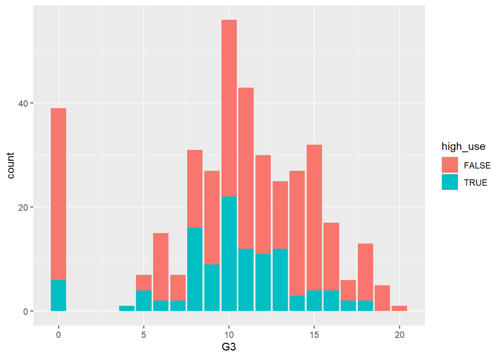

```r
ggplot(data = alc, aes(x = G3, fill = high_use)) + geom_bar()
```

```r
table(highuse = alc$high_use, grades = alc$G3)
```

```
##        grades
## highuse  0  4  5  6  7  8  9 10 11 12 13 14 15 16 17 18 19 20
##   FALSE 33  0  3 13  5 15 18 34 31 19 13 24 28 13  4 11  5  1
##   TRUE   6  1  4  2  2 16  9 22 12 11 12  3  4  4  2  2  0  0
```

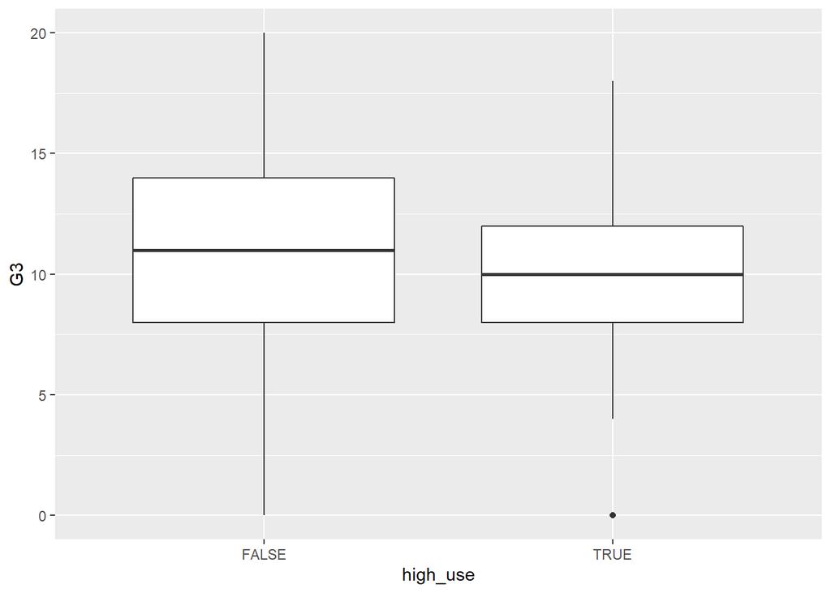

```r
ggplot(alc, aes(x = high_use, y = G3)) + geom_boxplot()
```

Students with the highest grades seem to mostly be in the lower use category.

Let’s look at family support next.

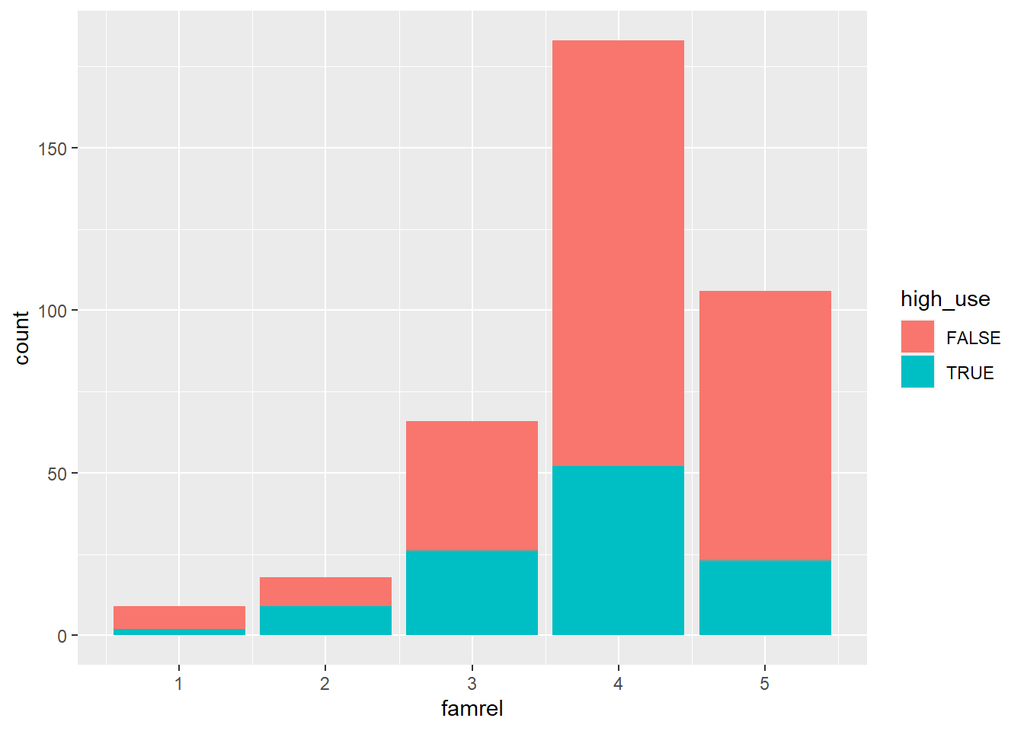

```r
ggplot(data = alc, aes(x = famrel, fill = high_use)) + geom_bar()
```

```r
table(highuse = alc$high_use, family = alc$famrel)
```

```
##        family
## highuse   1   2   3   4   5
##   FALSE   7   9  40 131  83
##   TRUE    2   9  26  52  23
```

```r
for (i in sort(unique(alc$famrel))) {
  sub = alc[alc$famrel==i,]
  high = sum(sub$high_use==TRUE)
  low = sum(sub$high_use==FALSE)
  ratio = round(high/(low + high)*100, digits = 2)
  print(paste(toString(ratio), "% of students with a family relationship of", toString(i), "are in the high alcohol category."))

}
```

```
## [1] "22.22 % of students with a family relationship of 1 are in the high alcohol category."
## [1] "50 % of students with a family relationship of 2 are in the high alcohol category."
## [1] "39.39 % of students with a family relationship of 3 are in the high alcohol category."
## [1] "28.42 % of students with a family relationship of 4 are in the high alcohol category."
## [1] "21.7 % of students with a family relationship of 5 are in the high alcohol category."
```

It certainly looks like a high family relationship predicts a lower use of alcohol (at least when famrel >= 2. Relatively low number samples in the famrel == 1 category might explain the low ration of high alcohol consumption).

Then absences.

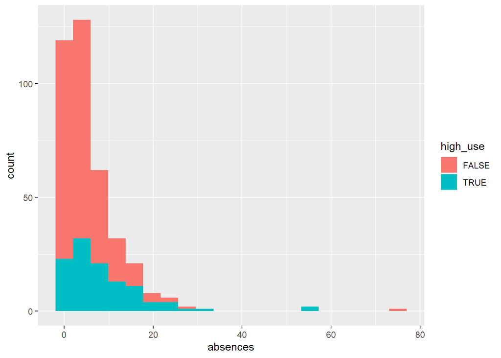

```r
ggplot(data = alc, aes(x = absences, fill = high_use)) + geom_histogram(bins = 20)
```

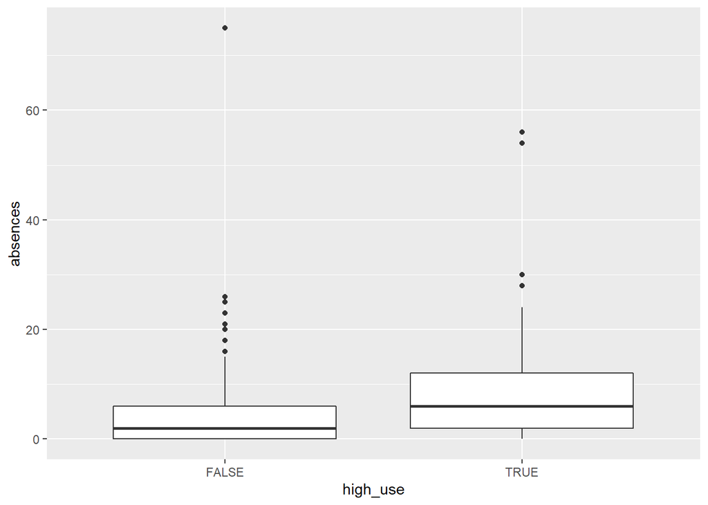

```r
ggplot(alc, aes(x = high_use, y = absences)) + geom_boxplot()
```

Hmm… A bit hard to make out, but it looks like those with more absences are more likely to be in the high use category.

Finally,lets look at age

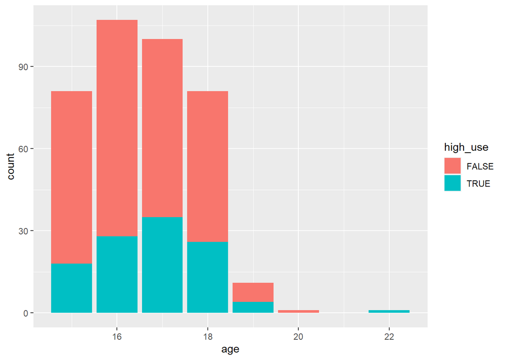

```r
ggplot(data = alc, aes(x = age, fill = high_use)) + geom_bar()
```

```r
table(highuse = alc$high_use, age = alc$age)
```

```
##        age
## highuse 15 16 17 18 19 20 22
##   FALSE 63 79 65 55  7  1  0
##   TRUE  18 28 35 26  4  0  1
```

```r
for (i in sort(unique(alc$age))) {
  sub = alc[alc$age==i,]
  high = sum(sub$high_use==TRUE)
  low = sum(sub$high_use==FALSE)
  ratio = round(high/(low + high)*100, digits = 2)
  print(paste(toString(ratio), "% of students of the age of", toString(i), "are in the high alcohol category."))

}
```

```
## [1] "22.22 % of students of the age of 15 are in the high alcohol category."
## [1] "26.17 % of students of the age of 16 are in the high alcohol category."
## [1] "35 % of students of the age of 17 are in the high alcohol category."
## [1] "32.1 % of students of the age of 18 are in the high alcohol category."
## [1] "36.36 % of students of the age of 19 are in the high alcohol category."
## [1] "0 % of students of the age of 20 are in the high alcohol category."
## [1] "100 % of students of the age of 22 are in the high alcohol category."
```

It looks like alcohol consumption somewhat jumps up at at the age 17 and above.

### 3.5 Logistic Regression

```r
logreg <- glm(high_use ~ G3 + famrel + absences + age, data = alc, family = "binomial")
summary(logreg)
```

```
##
## Call:
## glm(formula = high_use ~ G3 + famrel + absences + age, family = "binomial",
##     data = alc)
##
## Deviance Residuals:
##     Min       1Q   Median       3Q      Max
## -2.7108  -0.8076  -0.6780   1.2143   1.9825
##
## Coefficients:
##              Estimate Std. Error z value Pr(>|z|)
## (Intercept) -2.645322   1.795231  -1.474 0.140609
## G3          -0.009729   0.025802  -0.377 0.706121
## famrel      -0.277364   0.122979  -2.255 0.024110 *
## absences     0.062522   0.017618   3.549 0.000387 ***
## age          0.155649   0.102233   1.522 0.127887
## ---
## Signif. codes:  0 '***' 0.001 '**' 0.01 '*' 0.05 '.' 0.1 ' ' 1
##
## (Dispersion parameter for binomial family taken to be 1)
##
##     Null deviance: 462.21  on 381  degrees of freedom
## Residual deviance: 436.02  on 377  degrees of freedom
## AIC: 446.02
##
## Number of Fisher Scoring iterations: 4
```

Both family relationship and absences have a significant effect. Neither age or grades have a significant effect.

Let’s look at the odd ratios and their 95% confidence intervals.

```r
exp(cbind(coef(logreg), confint(logreg)))
```

```
##                              2.5 %    97.5 %
## (Intercept) 0.07098251 0.002037894 2.3734971
## G3          0.99031793 0.941826103 1.0423755
## famrel      0.75777871 0.594401560 0.9644452
## absences    1.06451794 1.030446671 1.1039063
## age         1.16841640 0.956650325 1.4300500
```

Increase of one in absences increases the odds of a student being in the high alcohol use category by approximately 1.06. (lower and upper boundaries of 1.03 and 1.10). While this might seem low considering that a student can have lots of absences this can actually a relatively large effect. For example, for a student with 20 absences, the model would predict the odds of being in the high alcohol category would rise to approximately 3.2 times that of a student with no absences.

In summary, the model supports our hypotheses about absences and family relationships, but not grades or age.

### 3.5 Predictive power of the model

Let’s explore the predictive power of the model

```r
prob <- predict(logreg, type = "response")

alc <- mutate(alc, probability = prob)
alc <- mutate(alc, prediction = prob > 0.5)
table(high_use = alc$high_use, prediction = alc$prediction)
```

```
##         prediction
## high_use FALSE TRUE
##    FALSE   260   10
##    TRUE     98   14
```

The training error is (98 + 10)/382 = 0.283 with most errors being false negatives. This is certainly better than guessing at 50% probability, but given that only about 30% of students are in the high alcohol use category are in the first place, it’s actually not all that much better than just assuming that a student is in the low-alcohol consumption group.